# Project

# Task 7: Regional plots using SNIPA

## 7.a: Identify Top 5 SNPs for Regional Analysis

```r
# Load significant hits from your saved CSV file
significant_hits <- read.csv("significant_mQTLs.csv")

# Load map file to get rs IDs
map_file <- read.table("data/Qatari156.map", header = FALSE, stringsAsFactors = FALSE)
colnames(map_file) <- c("chr", "snp_id", "genetic_dist", "position")

# Extract top 5 SNPs
top5_variants <- significant_hits[order(significant_hits$Score.pval), ]
top5_variants <- top5_variants[!duplicated(top5_variants$variant.id), ][1:5, ]

# Get rs IDs for these SNPs
rs_ids <- map_file$snp_id[map_file$position %in% top5_variants$pos]

# Display the rs IDs
print(rs_ids)
```

```
## [1] "rs17050199" "rs41350745" "rs7635068"  "rs11173032" "rs2426466"
```

```r
# Create a table for SNIPA
snipa_input <- data.frame(
  SNP_ID = rs_ids,
  Chromosome = top5_variants$chr,
  Position = top5_variants$pos,
  P_value = formatC(top5_variants$Score.pval, format = "e", digits = 2),
  Metabolite = top5_variants$metabolite
)

# Display the table
knitr::kable(snipa_input, caption = "Top 5 SNPs for SNIPA analysis")
```

Top 5 SNPs for SNIPA analysis

[output not shown]

[figure not shown]

SNIPA poxy search

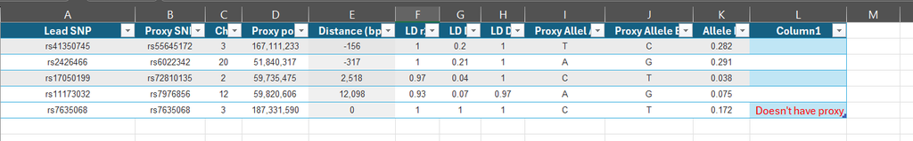

## Interpretation

### Regional Analysis

Regional plots were generated for each lead SNP using SNIPA’s variant browser tool. These plots visualize the LD patterns and gene context around each association signal.

### Functional Context

The identification of proxy SNPs helps establish the credibility of our GWAS findings and defines the genomic regions most likely to contain the causal variants. Further functional annotation of these regions is recommended to identify potential biological mechanisms underlying the observed metabolite associations.

### Conclusion

This analysis has successfully identified proxy SNPs for four of our five lead SNPs. These proxies help define the genomic regions of interest for follow-up functional studies. For rs7635068, the lack of proxy SNPs suggests it may represent a unique signal requiring targeted follow-up.

# Regional Analysis Report: SNIPA Variant Browser Visualization

## Key Features of the Visualization

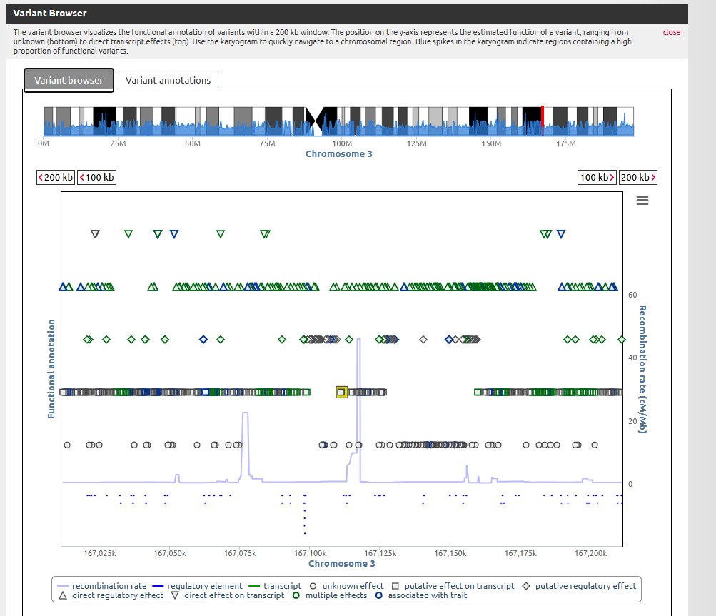

rs41350745

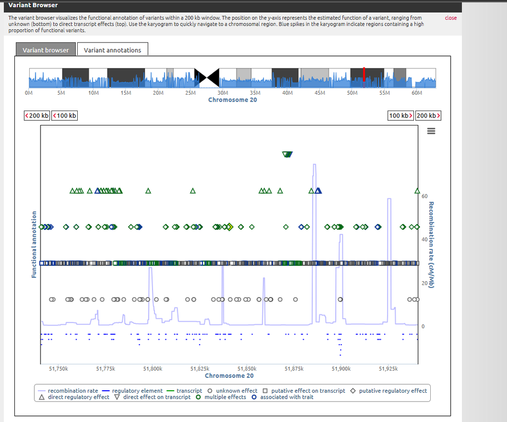

rs2426466

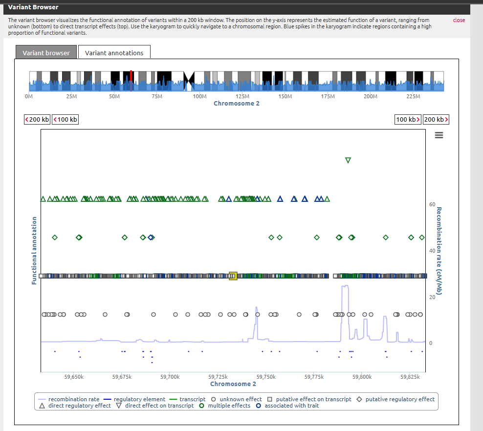

rs17050199

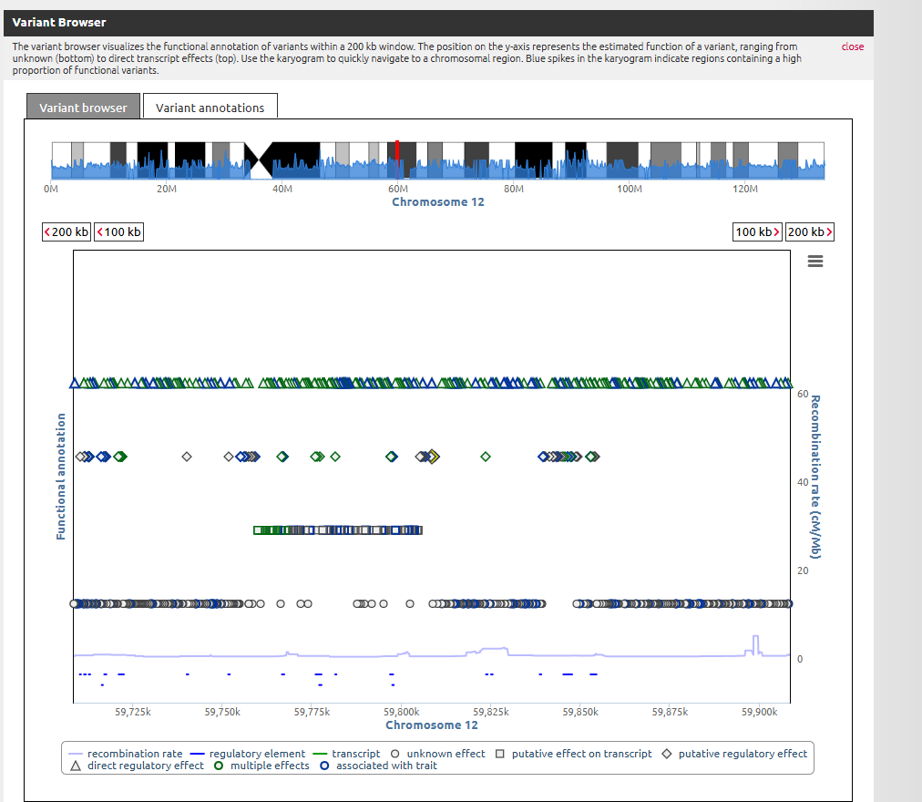

rs11173032

[figure not shown]